# Australia RSPCA

Simone Famiano

2022-06-01

[figure not shown]

## RSPCA

RSPCA Australia (Royal Society for the Prevention of Cruelty to Animals) is an Australian organisation established in 1981 to promote animal welfare.

RSPCA Australia defines its purpose as being the leading authority in animal care and protection, and to prevent cruelty to animals by actively promoting their care and protection.

With their mission for animal welfare in mind, this analysis will focus the numbers and type of animal complains RSPCA dealt over the last decade and their outcome. The aim is to point any KPI over time in a suburb, urban and national scale, so to identify focal point of interest for the organisation.

The analysis is aiming to answer these questions:

**• What is the total call volume for complaint calls regarding pets in Brisbane and Townsville?**

**• Is there a particular animal being called about the most?**

**• Do particular suburbs have different type of complaint calls?**

**• How have the different outcomes trended over time? Did RSPCA work have an impact?**

**• Using the insights found, can we predict how this might look for the upcoming year?**

## Data sources

This data comes from three sources:

• The Open RSPCA database

• Townsville Animal Complaints

• Brisbane Open Data - Animal Complaints

The **Open RSPCA database** contains annual statistics on the numbers of animals received, reclaimed or rehomed. These are compiled on a national basis by RSPCA Australia.

**Townsville Animal Complaints** lists of grievances received by Townsville City Council from 2013 to 2022 including animal type (cat/dog), complaint type, suburb and local government electoral division. Dataset is based on the 6 primary complaint categories of noise, wandering, enclosure, aggressive animal, attack and private impound.

**Brisbane Open Data** is a report on the total animal related complaints received in a quarter by Brisbane City Council. Information includes basic detail around the nature/type of the complaint and the suburb.

The three data sets are composed in both categorical and numerical variables (i.e. `animal_type` and `total_outcomes`). They all came in .csv file format.

I don’t have found any reason that suggests the data is biased, although it could have been more inclusive, in particular geographically.

The data sets differ from each other in scale; the RSPCA gives a national view on animal complaints outcomes, while the Townsville and Brisbane are generated by the local authority and cover complaints type and numbers in their respective area.

Although the last two data sets are very useful for a comparison between two different realities (Brisbane is the largest city in Australia and third by population, while Townsville is half the size and has 1/10 of the population), it would have been more insightful to have further data from a similar reality (for example Melbourne to compare with Brisbane and Darwin to compare with Townsville).

I have also noticed that the more prevalent animal types in the data set are dogs and cats, but this could be due more simply by the fact that they are the most popular pets. In the Brisbane data set is not often clear what animal is the subject of the complaint or sometime is describe simply as `wildlife`.

The complaints outcome data presents the outcome type, totals and animal type. Would have been interesting if it had included some further info for example the age of the animal to check if it affected the outcome.

## Ethics

Nothing concerning about ethics in the data sets. There no personal information on pet owners or people who started a complain, nor any identification for the pets (i.e. chip number etc.)

House pets are described generically as `Dogs`, `Cats` and `Other animals`.

There is no information on breed or background, which if it were the other way around, could have easily led to clickbait tabloid-ish insight like *“most dangerous dog”* and such, when the reason for collecting the data wasn’t certainly this one.

Same applies for non-house pets, we have very generic names: `Livestock`, `Wildlife` and `Horses`.

## Analysis

As mentioned above, the roots of the analysis will be 5 questions:

**• What is the total call volume for complaint calls regarding pets in Brisbane and Townsville?**

**• Is there a particular animal being called about the most?**

**• Do particular suburbs have different type of complaint calls?**

**• How have the different outcomes trended over time? Did RSPCA work have an impact?**

**• Using the insights found, can we predict how this might look for the upcoming year?**

All the process, from data cleaning to data analysis will be done in R Studio.

The slides for the presentation will be generated in PowerPoint.

The analysis itself will be a Descriptive Analytics on the complaints received by RSPCA in the city of **Brisbane** and the city of **Townsville**. This part of the analysis will concentrate on the first three questions.

*• What is the total call volume for complaint calls regarding pets in Brisbane and Townsville?*

*• Is there a particular animal being called about the most?*

*• Do particular suburbs have different type of complaint calls?*

It will be interesting to point any difference of KPIs in the two locations and if there is any hypothesize why.

The second part of the analysis will be investigating the outcome of complaints on a national scale, analysing the trend over the years.

*• How have the different outcomes trended over time? Did RSPCA work have an impact?*

The third and final part will be a Predictive Analytics on the outcome of complaints trend for the next year.

*• Using the insights found, can we predict how this might look for the upcoming year?*

I consider this part as an extension, so it will appear in the final project unless any major issue such as bad time management etc.

## The analysis

Libraries:

```r
library(rpart)
library(rpart.plot)
library(here)
library(forcats)
library(janitor)
library(tidyverse)
```

The Data:

```r
townsville_complaints <- read_csv(here(
  "clean_data/townsville_complaints_clean.csv")
  )
townsville_complaints_tot_per_suburb <- read_csv(here(
  "clean_data/townsville_complaints_tot_per_suburb.csv")
  )
national_outcomes <- read_csv(here(
  "clean_data/national_outcomes_clean.csv")
  )
brisbane_complaints <- read_csv(here(
  "clean_data/brisbane_complaints_clean.csv")
  ) %>%
  mutate(suburb = str_to_title(suburb)
         )
brisbane_complaints_tot_per_suburb <- read_csv(here(
  "clean_data/brisbane_complaints_tot_per_suburb.csv")
  ) %>%
  mutate(suburb = str_to_title(suburb)
         )
townsville_complaints
```

```
## # A tibble: 42,413 x 4
##    animal_type complaint_type    date_received suburb
##    <chr>       <chr>             <chr>         <chr>
##  1 dog         Aggressive Animal June 2020     Alice River
##  2 dog         Noise             June 2020     Alice River
##  3 dog         Noise             June 2020     Alice River
##  4 dog         Private Impound   June 2020     Alice River
##  5 dog         Wandering         June 2020     Alice River
##  6 dog         Attack            June 2020     Black River
##  7 dog         Enclosure         June 2020     Black River
##  8 dog         Wandering         June 2020     Black River
##  9 dog         Enclosure         June 2020     Bluewater
## 10 dog         Enclosure         June 2020     Bluewater
## # ... with 42,403 more rows
```

```r
townsville_complaints_tot_per_suburb
```

```
## # A tibble: 600 x 4
##    animal_type complaint_type suburb         total
##    <chr>       <chr>          <chr>          <dbl>
##  1 cat         Enclosure      Aitkenvale        16
##  2 cat         Enclosure      Alice River        4
##  3 cat         Enclosure      Annandale         20
##  4 cat         Enclosure      Arcadia            1
##  5 cat         Enclosure      Black River        3
##  6 cat         Enclosure      Bohle Plains      12
##  7 cat         Enclosure      Burdell           22
##  8 cat         Enclosure      Bushland Beach    25
##  9 cat         Enclosure      Castle Hill        1
## 10 cat         Enclosure      Cluden             1
## # ... with 590 more rows
```

```r
brisbane_complaints
```

```
## # A tibble: 31,330 x 4
##    animal_type category             suburb          date_range
##    <chr>       <chr>                <chr>           <chr>
##  1 Dog         Fencing Issues       Sunnybank       january march 2016
##  2 Dog         Fencing Issues       Sunnybank Hills january march 2016
##  3 Dog         Defecating In Public Sunnybank       january march 2016
##  4 Dog         Fencing Issues       Sunnybank       january march 2016
##  5 Attack      Attack On An Animal  Calamvale       january march 2016
##  6 Attack      Attack On A Person   Stretton        january march 2016
##  7 Dog         Fox                  Annerley        january march 2016
##  8 Attack      Attack On An Animal  Forest Lake     january march 2016
##  9 Dog         Fencing Issues       Hawthorne       january march 2016
## 10 Dog         Defecating In Public Hawthorne       january march 2016
## # ... with 31,320 more rows
```

```r
brisbane_complaints_tot_per_suburb
```

```
## # A tibble: 3,571 x 4
##    animal_type category           suburb       total
##    <chr>       <chr>              <chr>        <dbl>
##  1 Attack      Attack On A Person Acacia Ridge    39
##  2 Attack      Attack On A Person Albion           1
##  3 Attack      Attack On A Person Alderley        13
##  4 Attack      Attack On A Person Algester        13
##  5 Attack      Attack On A Person Annerley        11
##  6 Attack      Attack On A Person Anstead          7
##  7 Attack      Attack On A Person Archerfield      2
##  8 Attack      Attack On A Person Ascot            7
##  9 Attack      Attack On A Person Ashgrove        27
## 10 Attack      Attack On A Person Aspley          34
## # ... with 3,561 more rows
```

```r
national_outcomes
```

```
## # A tibble: 5,312 x 5
##     year animal_type outcome   state                        tot_outcomes
##    <dbl> <chr>       <chr>     <chr>                               <dbl>
##  1  1999 Dogs        Reclaimed Australian Capital Territory          610
##  2  1999 Dogs        Reclaimed New South Wales                      3140
##  3  1999 Dogs        Reclaimed Northern Territory                    205
##  4  1999 Dogs        Reclaimed Queensland                           1392
##  5  1999 Dogs        Reclaimed South Australia                      2329
##  6  1999 Dogs        Reclaimed Tasmania                              516
##  7  1999 Dogs        Reclaimed Victoria                             7130
##  8  1999 Dogs        Reclaimed Western Australia                       1
##  9  1999 Dogs        Rehomed   Australian Capital Territory         1245
## 10  1999 Dogs        Rehomed   New South Wales                      7525
## # ... with 5,302 more rows
```

In the cleaning script, from the three raw data sets I have got five clean data set to use for the analysis. The Townsville and Brisbane data sets were cleaned and divided in two: one with the total cases by suburbs and the other keeping `date_received` and `date_range` column. I felt having separated data sets with information on time would have been better, rather than include them with the row totals. An analysis of the complaints over time wasn’t part of my MVP but rather an extension, so it would make sense to have this two data sets on the side in case I decided to go for it.

The national outcome is a long list of outcomes per animal in every Australian State from 1999 to 2018.

Let’s start to look at the complaing type in Townsville.

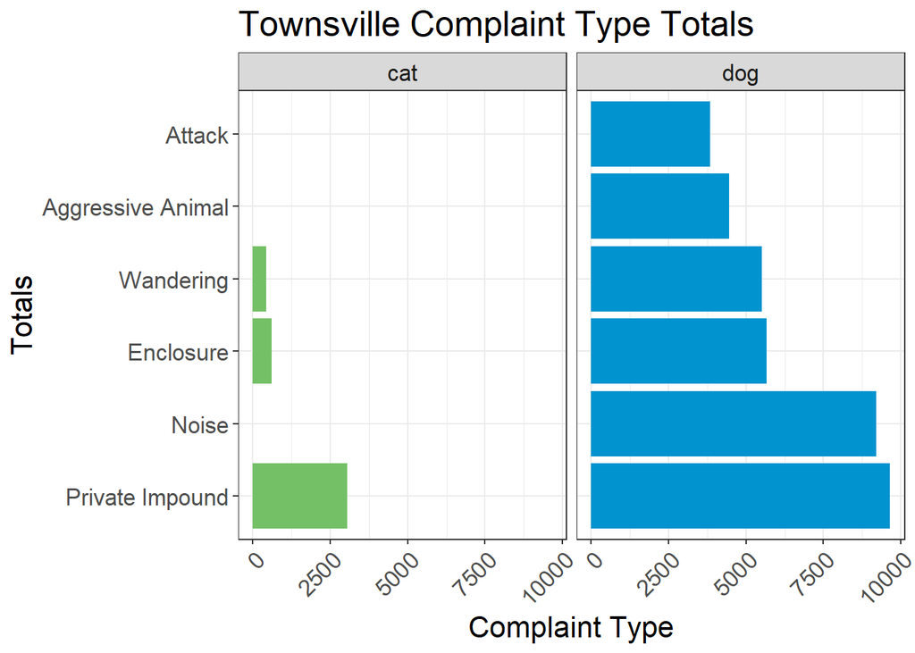

```r
townsville_complaints_tot_plot <- townsville_complaints %>%
  ggplot() +
  geom_bar(aes(y = fct_infreq(complaint_type),
                                   fill = animal_type)) +
  labs(x = "Complaint Type",
       y = "Totals",
       title = "Townsville Complaint Type Totals") +
  scale_fill_manual("Animal Type", values = c("cat" = "#74c066",
                                              "dog" = "#0193cf")
                    ) +
  theme_bw() +
  theme(text=element_text(size = 16, family = "Arial"),
        axis.text.x = element_text(angle = 45, hjust = 1),
        legend.position = "none") +
  facet_wrap(~ animal_type)


townsville_complaints_tot_plot
```

In Townsville, dogs receive the more complaints. Calls regarding Cats are more concentrated on the welfare of the animal rather than proper annoyance like in dogs

[output not shown]

[output not shown]

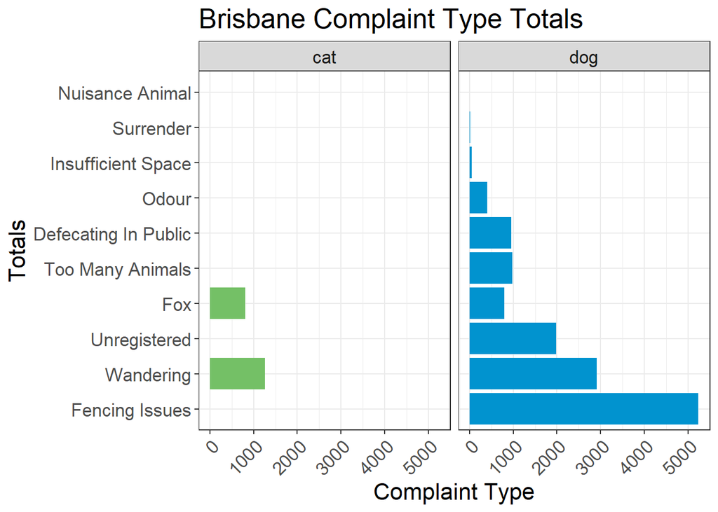

```r
exclude <- c("Dog")

brisbane_complaints_tot_plot <- brisbane_complaints %>%
  mutate(animal_type = str_to_lower(animal_type)) %>%
  filter(animal_type %in% "cat" | animal_type %in% "dog") %>%
  filter(!category %in% exclude) %>%
  ggplot() +
  geom_bar(aes(y = fct_infreq(category), fill = animal_type)) +
  labs(x = "Complaint Type",
       y = "Totals",
       title = "Brisbane Complaint Type Totals") +
  scale_fill_manual("Animal Type", values = c("cat" = "#74c066",
                                              "dog" = "#0193cf")
                    ) +
  theme_bw() +
  theme(text=element_text(size = 16, family = "Arial"),
        axis.text.x = element_text(angle = 45, hjust = 1),
        legend.position = "none") +
  facet_wrap(~ animal_type)


brisbane_complaints_tot_plot
```

In Brisbane again, dogs are again the focus of complains. We can notice some difference from Townsville, there is more variety of complains and looks like in Brisbane dogs have something for fences. Also, it seems to be an issue with foxes. Let’s look at this further.

## Brisbane vs Fox

[output not shown]

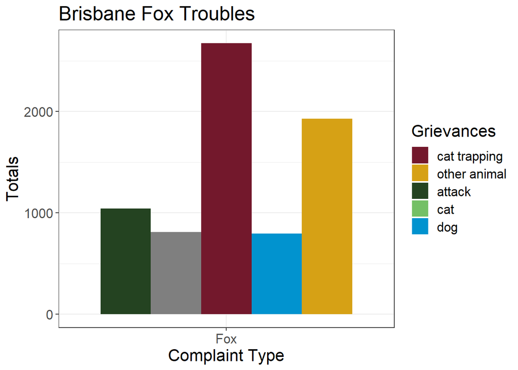

```r
include <- "Fox"

brisbane_complaints_fox_plot <- brisbane_complaints %>%
  mutate(animal_type = str_to_lower(animal_type)) %>%
 # filter(!animal_type %in% "cat" | animal_type %in% "dog") %>%
  filter(category %in% include) %>%
  ggplot() +
  geom_bar(position = "dodge", aes(x = category, fill = animal_type)) +
  labs(x = "Complaint Type",
       y = "Totals",
       title = "Brisbane Fox Troubles") +
  scale_fill_manual("Grievances", values = c("cat trapping" = "#73182c",
                                             "other animal" = "#d6a115",
                                             "attack" = "#244321",
                                             "cat " = "#74c066",
                                             "dog" = "#0193cf")
                    ) +
  theme_bw() +
  theme(text=element_text(size = 16, family = "Arial"))

brisbane_complaints_fox_plot
```

A fair amount of complaints are regarding foxes attacking dogs and cats and in particular trapping the latter. **Advise business to do campaign on keeping pets inside at home, in particular cats, as long as it necessary.**

[output not shown]

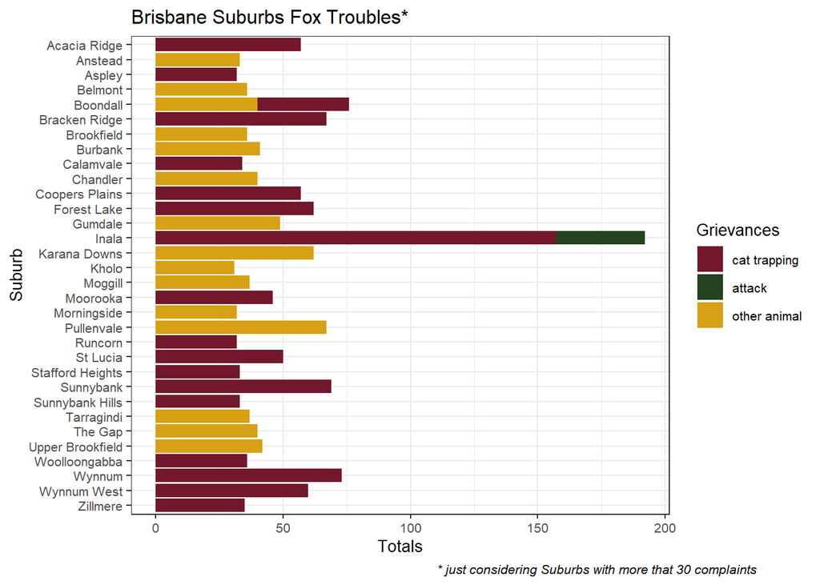

```r
brisbane_complaints_fox_per_suburbs <- brisbane_complaints_tot_per_suburb %>%
  mutate(animal_type = str_to_lower(animal_type)) %>%
  #filter(!animal_type %in% "cat" | animal_type %in% "dog") %>%
  filter(category %in% include) %>%
  filter(total > 30) %>%
  ggplot() +
  geom_col(aes(y = suburb, x = total, fill = animal_type)) +
  labs(y = "Suburb",
       x = "Totals",
       title = "Brisbane Suburbs Fox Troubles*",
       caption = "* just considering Suburbs with more that 30 complaints") +
  scale_fill_manual("Grievances", values = c("cat trapping" = "#73182c",
                                              "attack" = "#244321",
                                              "other animal" = "#d6a115")
                    ) +
  scale_y_discrete(limits = rev) +
  theme_bw() +
  theme(text=element_text(size = 10, family = "Arial"),
        plot.caption = element_text(hjust = 1.4, face = "italic"))

brisbane_complaints_fox_per_suburbs
```

If we look at the fox problem by suburb, we notice that the cat trapping issue is particularly felt in Inala. Probably because this is a more remote area. **It would be good to consider this particular area to address a “keep pets at home” campaign.**

[output not shown]

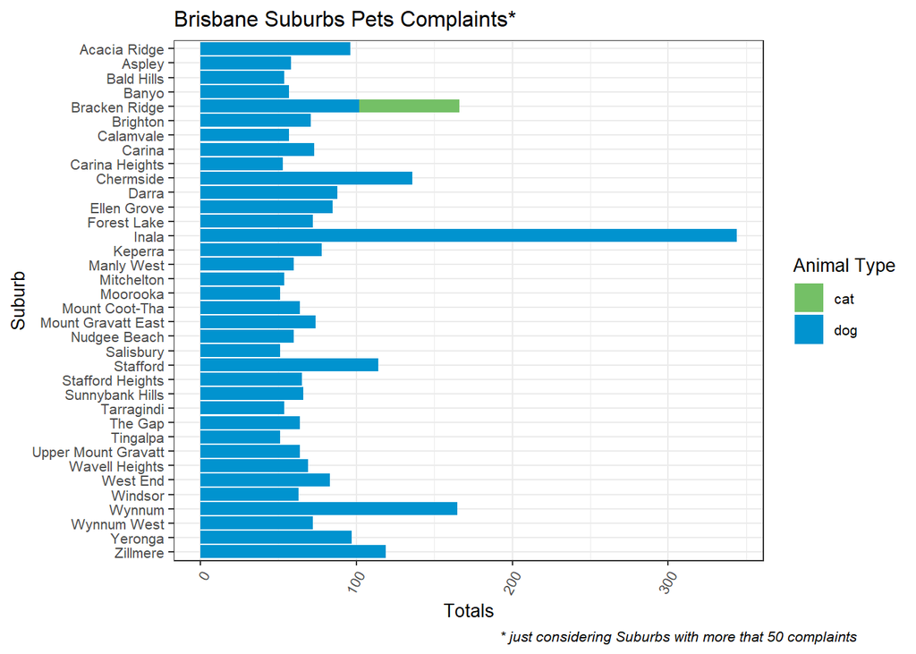

```r
brisbane_complaints_by_suburbs <- brisbane_complaints_tot_per_suburb %>%
  mutate(animal_type = str_to_lower(animal_type)) %>%
  filter(animal_type %in% "cat" | animal_type %in% "dog") %>%
  filter(!category %in% exclude) %>%
  filter(total > 50) %>%
  drop_na() %>%
  ggplot() +
  geom_col(aes(y = suburb, x = total, fill = animal_type)) +
  labs(y = "Suburb",
       x = "Totals",
       title = "Brisbane Suburbs Pets Complaints*",
       caption = "* just considering Suburbs with more that 50 complaints") +
   scale_fill_manual("Animal Type", values = c("cat" = "#74c066",
                                              "dog" = "#0193cf")
                    ) +
  scale_y_discrete(limits = rev) +
  theme_bw() +
  theme(text=element_text(size = 10, family = "Arial"),
        axis.text.x = element_text(angle = 60, hjust = 1),
        plot.caption = element_text(hjust = 1.4, face = "italic"))

brisbane_complaints_by_suburbs
```

[output not shown]

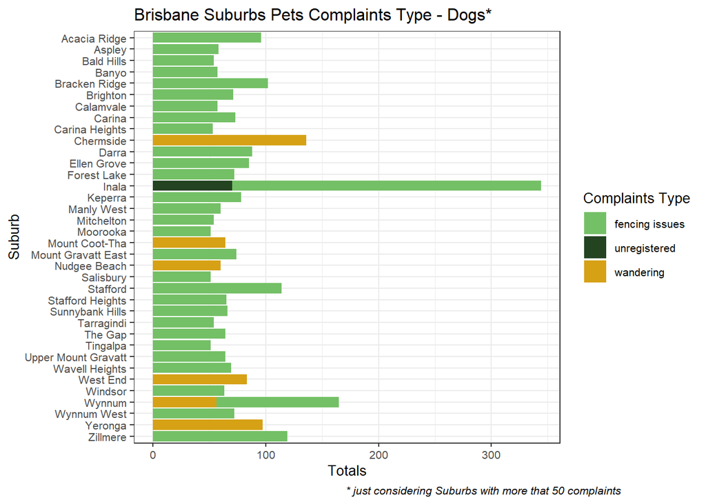

```r
brisbane_subs_complaints_type_dogs <- brisbane_complaints_tot_per_suburb %>%
  mutate(category = str_to_lower(category)) %>%
  filter(animal_type == "Dog") %>%
  filter(!category %in% exclude) %>%
  filter(total > 50) %>%
  drop_na() %>%
  ggplot() +
  geom_col(aes(y = suburb, x = total, fill = category)) +
  labs(y = "Suburb",
       x = "Totals",
       title = "Brisbane Suburbs Pets Complaints Type - Dogs*",
       caption = "* just considering Suburbs with more that 50 complaints") +
  scale_fill_manual("Complaints Type", values = c("fencing issues" = "#74c066",
                                                  "unregistered" = "#244321",
                                                  "wandering" = "#d6a115")
                    ) +
  scale_y_discrete(limits = rev) +
  theme_bw() +
  theme(text=element_text(size = 10, family = "Arial"),
        plot.caption = element_text(hjust = 1.4, face = "italic"))

brisbane_subs_complaints_type_dogs
```

The majority of the complaints are regarding fencing issues, so most probably problems between neighbors. Again, most of the calls are from Inala.

[output not shown]

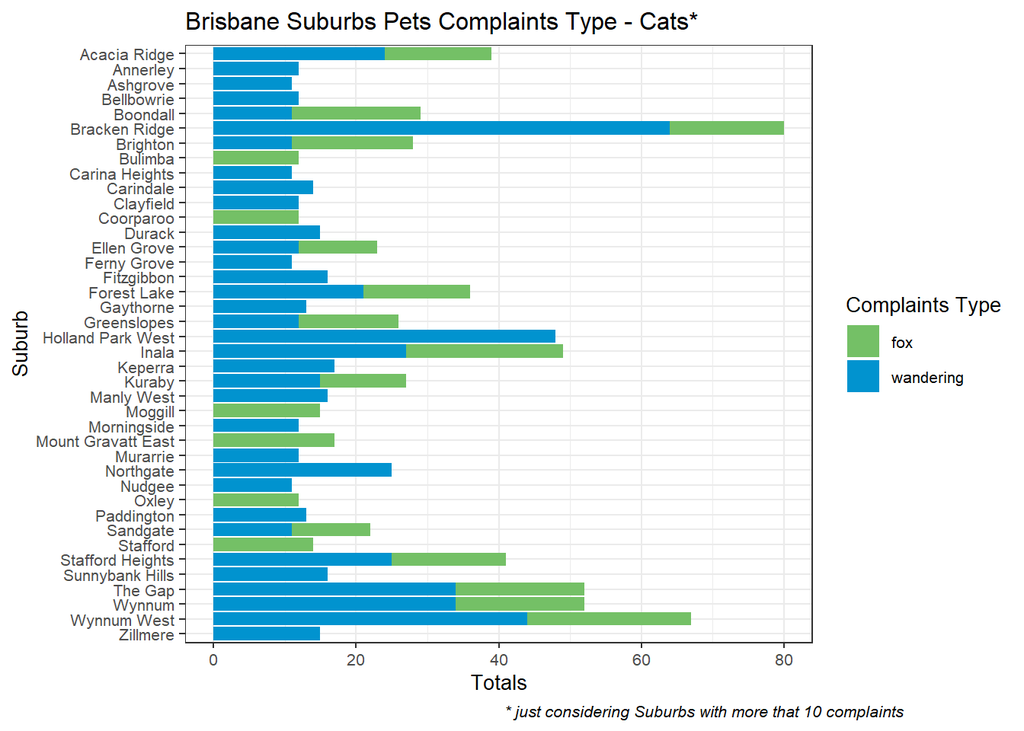

```r
brisbane_subs_complaints_type_cats <- brisbane_complaints_tot_per_suburb %>%
  mutate(category = str_to_lower(category)) %>%
  filter(animal_type == "Cat") %>%
  filter(!category %in% exclude) %>%
  filter(total > 10) %>%
  drop_na() %>%
  ggplot() +
  geom_col(aes(y = suburb, x = total, fill = category)) +
  labs(y = "Suburb",
       x = "Totals",
       title = "Brisbane Suburbs Pets Complaints Type - Cats*",
       caption = "* just considering Suburbs with more that 10 complaints") +
  scale_fill_manual("Complaints Type", values = c("fox" = "#74c066",
                                                  "wandering" = "#0193cf")
                    ) +
  scale_y_discrete(limits = rev) +
  theme_bw() +
  theme(text=element_text(size = 10, family = "Arial"),
        plot.caption = element_text(hjust = 1.4, face = "italic"))

brisbane_subs_complaints_type_cats
```

While for cats the majority of calls are regarding a lost or stray cats wandering. Plus the already mentioned, fox issue.

[output not shown]

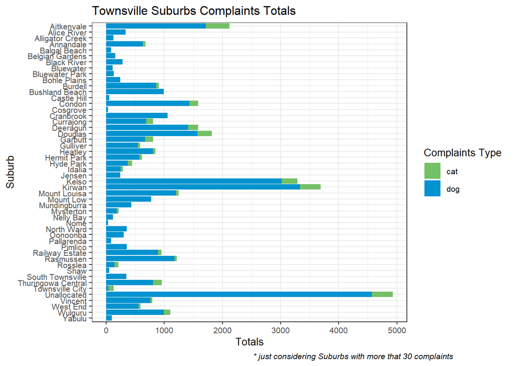

```r
townsville_complaints_by_suburbs <- townsville_complaints_tot_per_suburb %>%
  filter(total > 30) %>%
  ggplot() +
  geom_col(aes(y = suburb, x = total, fill = animal_type)) +
  labs(y = "Suburb",
       x = "Totals",
       title = "Townsville Suburbs Complaints Totals",
       caption = "* just considering Suburbs with more that 30 complaints") +
  scale_fill_manual("Complaints Type", values = c("cat" = "#74c066",
                                                  "dog" = "#0193cf")
                    ) +
  scale_y_discrete(limits = rev) +
  theme_bw() +
  theme(text=element_text(size = 10, family = "Arial"),
        plot.caption = element_text(hjust = 1.4, face = "italic"))

townsville_complaints_by_suburbs
```

Going back to Townsville and looking at its suburbs, dogs are at it again. Most complains are directed to dogs

[output not shown]

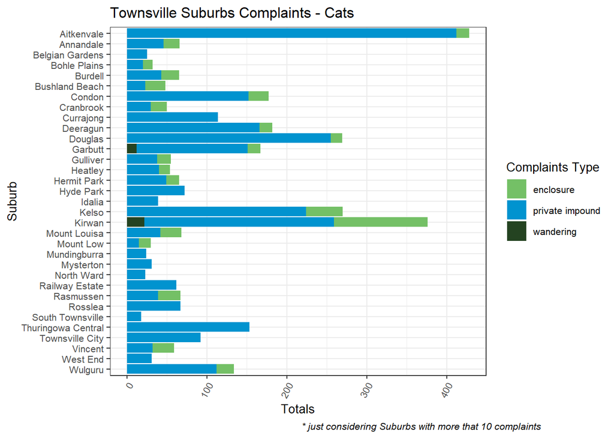

```r
townsville_complaints_type_cats <- townsville_complaints_tot_per_suburb %>%
  mutate(complaint_type = str_to_lower(complaint_type)) %>%
  filter(animal_type == "cat") %>%
  filter(total > 10) %>%
  filter(!suburb == "Unallocated") %>%
  ggplot() +
  geom_col(aes(y = suburb, x = total, fill = complaint_type)) +
  labs(y = "Suburb",
       x = "Totals",
       title = "Townsville Suburbs Complaints - Cats",
       caption = "* just considering Suburbs with more that 10 complaints") +
  scale_fill_manual("Complaints Type", values = c("enclosure" = "#74c066",
                                                  "private impound" = "#0193cf",
                                                  "wandering" = "#244321")
                    ) +
  scale_y_discrete(limits = rev) +
  theme_bw() +
  theme(text=element_text(size = 10, family = "Arial"),
        axis.text.x = element_text(angle = 60, hjust = 1),
        plot.caption = element_text(hjust = 1.4, face = "italic"))

townsville_complaints_type_cats
```

If we look at the complaints type for cats by suburbs, we see that the majority of calls for cat are for private impound which means that a person not associated with RSCA takes in a cat, in this case, and alert RSPCA after that. No foxes mentioned here.

[output not shown]

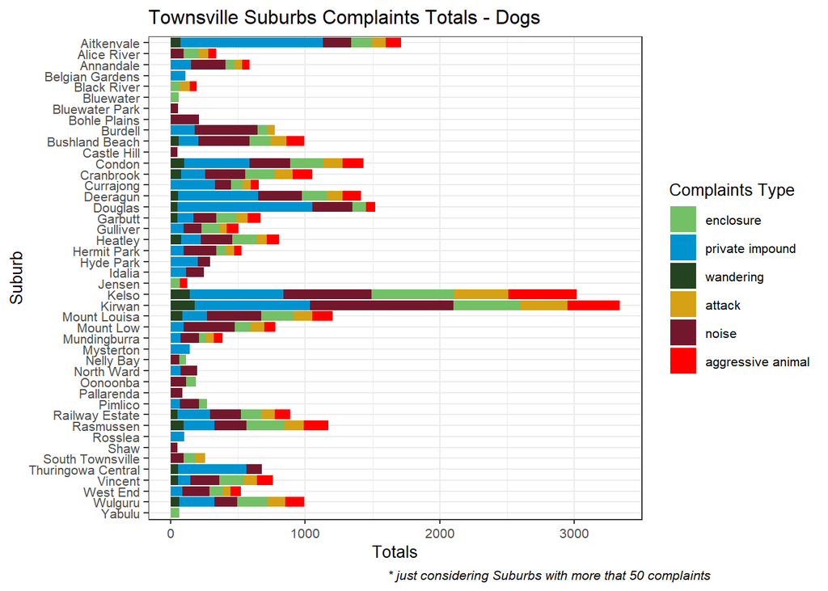

```r
townsville_complaints_type_dogs <- townsville_complaints_tot_per_suburb %>%
  mutate(complaint_type = str_to_lower(complaint_type)) %>%
  filter(!animal_type == "cat") %>%
  filter(total > 50) %>%
  filter(!suburb == "Unallocated") %>%
  ggplot() +
  geom_col(aes(y = suburb, x = total, fill = complaint_type)) +
  labs(y = "Suburb",
       x = "Totals",
       title = "Townsville Suburbs Complaints Totals - Dogs",
       caption = "* just considering Suburbs with more that 50 complaints") +
  scale_fill_manual("Complaints Type", values = c("enclosure" = "#74c066",
                                                  "private impound" = "#0193cf",
                                                  "wandering" = "#244321",
                                                  "attack" = "#d6a115",
                                                  "noise" = "#73182c",
                                                  "aggressive animal" = "#ff0000")
                    ) +
  scale_y_discrete(limits = rev) +
  theme_bw() +
  theme(text=element_text(size = 10, 0.1, family = "Arial"),
        plot.caption = element_text(hjust = 1.4, face = "italic"))

townsville_complaints_type_dogs
```

**RSPCA should probably further inquire on pets welfare in this suburbs and concentrate a campaign on how to be a good dog owner.**

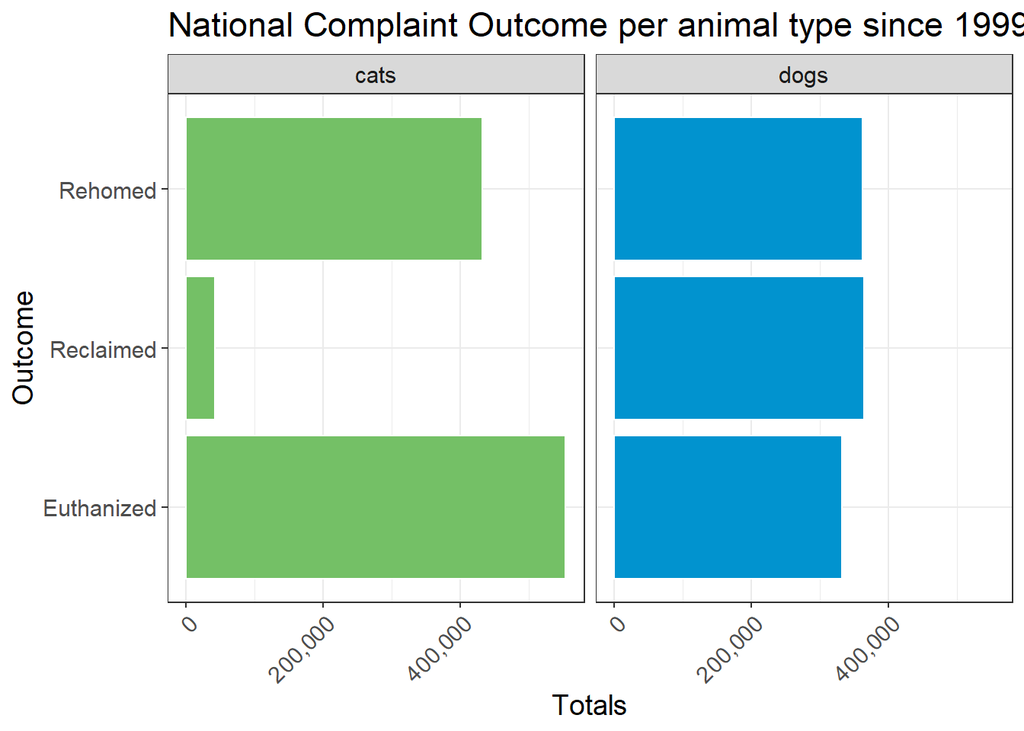

```r
national_outcomes_pets <-  national_outcomes %>%
  filter(!outcome == "Currently In Care") %>%
  filter(!outcome == "Other") %>%
  filter(animal_type == "Cats" | animal_type == "Dogs") %>%
  mutate(animal_type = str_to_lower(animal_type)) %>%
  group_by(animal_type, outcome) %>%
  summarise(tot = sum(tot_outcomes)) %>%
  drop_na() %>%
  ggplot() +
  geom_col(position = "dodge", colour = "white", aes(y = fct_infreq(outcome),
                                                     x = tot,
                                                     fill = animal_type)
           )+
  labs(y = "Outcome",
       x = "Totals",
       title = "National Complaint Outcome per animal type since 1999") +
  scale_fill_manual("Animal Type", values = c("cats" = "#74c066",
                                                  "dogs" = "#0193cf")
                    ) +
  scale_x_continuous(labels = scales::comma) +
  theme_bw() +
  theme(text=element_text(size = 14, family = "Arial"),
        axis.text.x = element_text(angle = 45, hjust = 1),
        legend.position = "none") +
  facet_wrap(~animal_type)
national_outcomes_pets
```

The most common outcome for cats is to be euthanised, and they are not reclaimed as often a dogs and I am not sure how many how the rehoming are successful. I can imagine that a cat that gets returned to RSPCA or ends up again in the street is not a rare scenario, that would explain the difference in numbers for euthanised and reclaimed with dogs.

```r
national_outcomes %>%
  filter(animal_type == "Cats" | animal_type == "Dogs") %>%
  group_by(animal_type) %>%
  drop_na() %>%
  summarise(tot_outcomes = sum(tot_outcomes))
```

```
## # A tibble: 2 x 2
##   animal_type tot_outcomes
##   <chr>              <dbl>
## 1 Cats             1117506
## 2 Dogs             1149320
```

The number of cats and dogs in the data set is almost equivalent so I tend to believe the above hypothesis.

[output not shown]

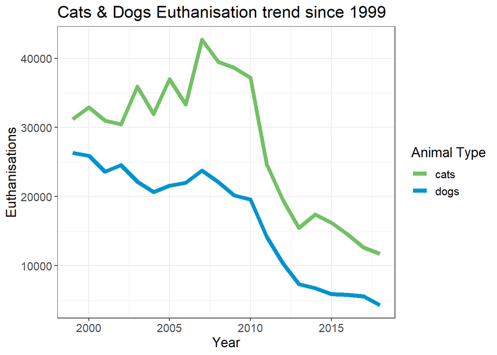

```r
euthanisation_trend_cats_dogs <- national_outcomes %>%
  filter(animal_type == "Cats" | animal_type == "Dogs") %>%
  filter(outcome == "Euthanized") %>%
  mutate(animal_type = str_to_lower(animal_type)) %>%
  group_by(year, animal_type, outcome) %>%
  summarise(tot_outcomes = sum(tot_outcomes)) %>%
  ungroup() %>%
  ggplot() +
  geom_line(size = 2,aes(x = year,
                         y = tot_outcomes,
                         group = animal_type,
                         colour = animal_type)
            ) +
  labs(x = "Year",
       y = "Euthanisations",
       title = "Cats & Dogs Euthanisation trend since 1999") +
  scale_colour_manual("Animal Type", values = c("cats" = "#74c066",
                                              "dogs" = "#0193cf")
                    ) +
  theme_bw() +
  theme(text=element_text(size = 14, family = "Arial"))
euthanisation_trend_cats_dogs
```

The good news is that the trend is changing, since the 2010s euthanisations have dropped drastically.

[output not shown]

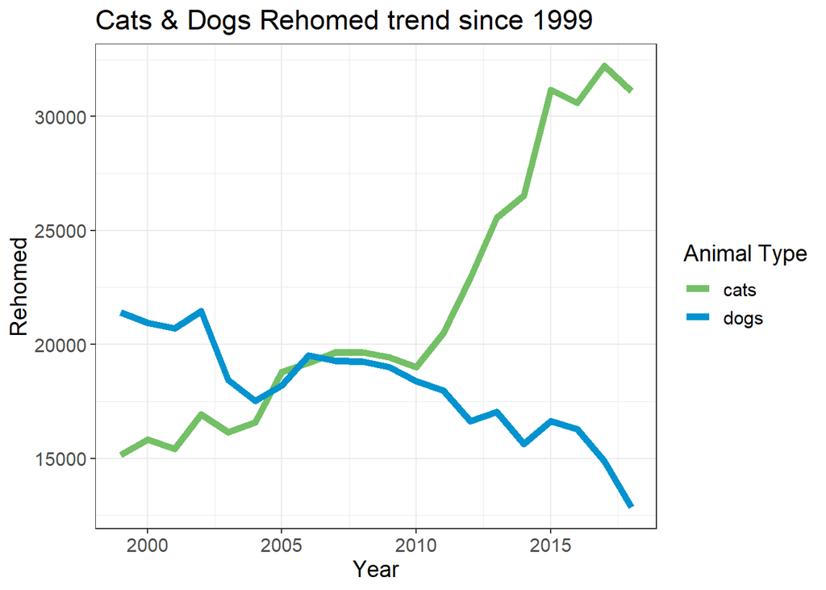

```r
rehoming_trendcats_dogs <- national_outcomes %>%
  filter(animal_type == "Cats" | animal_type == "Dogs") %>%
  filter(outcome == "Rehomed") %>%
  mutate(animal_type = str_to_lower(animal_type)) %>%
  group_by(year, animal_type, outcome) %>%
  summarise(tot_outcomes = sum(tot_outcomes)) %>%
  ungroup() %>%
  ggplot() +
  geom_line(size = 2,aes(x = year,
                         y = tot_outcomes,
                         group = animal_type,
                         colour = animal_type)
            ) +
  labs(x = "Year",
       y = "Rehomed",
       title = "Cats & Dogs Rehomed trend since 1999") +
  scale_colour_manual("Animal Type", values = c("cats" = "#74c066",
                                              "dogs" = "#0193cf")
                    ) +
  theme_bw() +
  theme(text=element_text(size = 14, family = "Arial"))
rehoming_trendcats_dogs
```

Rehoming numbers for cats have increase drastically since the 2010s, but again I have doubts on how many of these were successful.

[output not shown]

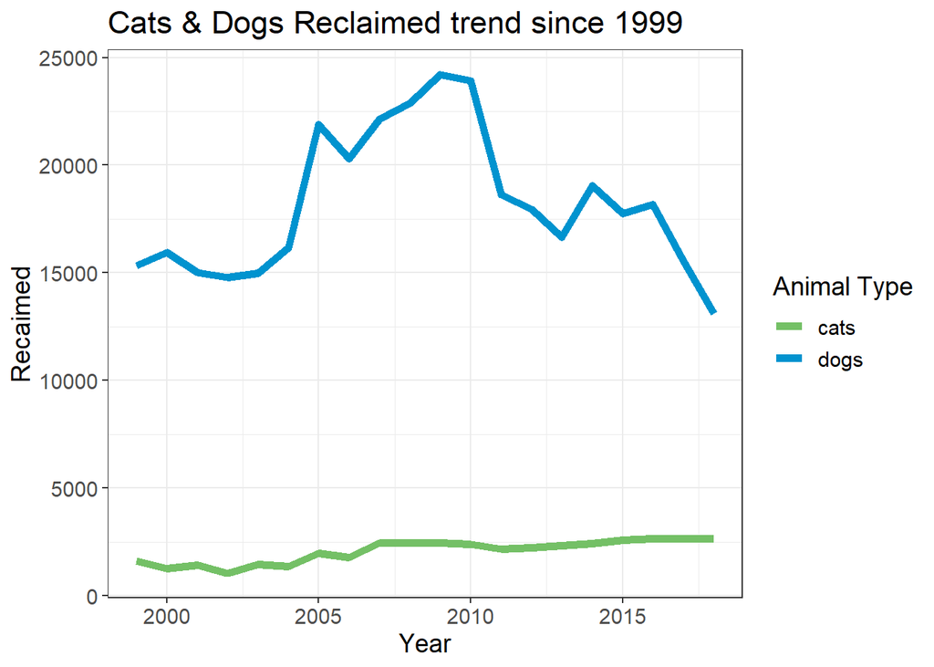

```r
reclaimed_trendcats_dogs <- national_outcomes %>%
  filter(animal_type == "Cats" | animal_type == "Dogs") %>%
  filter(outcome == "Reclaimed") %>%
  mutate(animal_type = str_to_lower(animal_type)) %>%
  group_by(year, animal_type, outcome) %>%
  summarise(tot_outcomes = sum(tot_outcomes)) %>%
  ungroup() %>%
  ggplot() +
  geom_line(size = 2,aes(x = year,
                         y = tot_outcomes,
                         group = animal_type,
                         colour = animal_type)
            ) +
  labs(x = "Year",
       y = "Recaimed",
       title = "Cats & Dogs Reclaimed trend since 1999") +
  scale_colour_manual("Animal Type", values = c("cats" = "#74c066",
                                              "dogs" = "#0193cf")
                    ) +
  theme_bw() +
  theme(text=element_text(size = 14, family = "Arial"))
reclaimed_trendcats_dogs
```

The reclaimed trends for cats hasn’t been that great and it’s stable during the years. For dog the trend is going down although this couldn’t been so gloom, with the diffusion of social media and in particular neighborhood pages, when a dog go missing the voice is spread quickly and usually they are found before RSPCA intervention.

**A campaing to invite cat owners to register and chip their cats probably would help in having better number for reclaimed cats**

## Preparing the data set for the decision tree

I will create three decision tree, one comparing the outcome with the state, one with the animal type and a last one with the whole data set.

```r
tree_national_outcomes <- rowid_to_column(national_outcomes, "id") %>%
  drop_na()

decision_tree_try <- data.frame(lapply(tree_national_outcomes,
                                       rep,
                                       tree_national_outcomes$tot_outcomes))
```

```r
clean_national_test <- decision_tree_try %>%
  #filter(year == "2018") %>%
  filter(animal_type == "Dogs" | animal_type == "Cats") %>%
  filter(outcome == "Euthanized" |
         outcome == "Rehomed" ) %>%
   mutate(animal_type = as.factor(animal_type),
         state = as.numeric(factor(state)),
         outcome = as.numeric(factor(outcome))
         ) %>%
  mutate(state = factor(state, levels = c(1,2,3,4,5,6,7,8),
                        labels = c("Australian Capital Territory",
                                   "New South Wales",
                                   "Northern Territory",
                                   "Queensland",
                                   "South Australia",
                                   "Tasmania",
                                   "Victoria",
                                   "Western Australia")),
         outcome = factor(outcome, levels = c(1,2),
                              labels = c("Euthanized", "Rehomed"))
         ) %>%
  select(-id, -tot_outcomes)

clean_national_test
```

[output not shown]

[output cut: 24986 more lines]

```r
n_data <- nrow(clean_national_test)

test_index <- sample(1:n_data, size = n_data*0.2)

outcomes_test  <- slice(clean_national_test, test_index)

outcomes_train <- slice(clean_national_test, -test_index)

outcomes_test %>%
  tabyl(outcome)
```

```
##     outcome      n   percent
##  Euthanized 177340 0.5274711
##     Rehomed 158868 0.4725289
```

```r
outcomes_train %>%
  tabyl(outcome)
```

```
##     outcome      n  percent
##  Euthanized 709163 0.527323
##     Rehomed 635673 0.472677
```

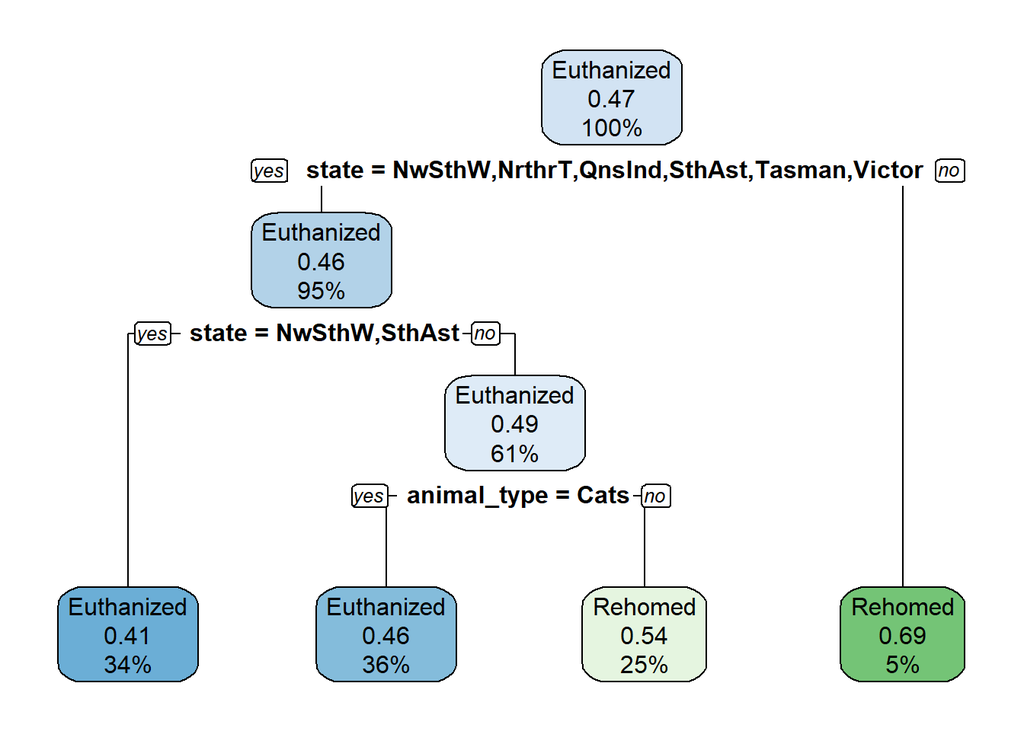

```r
outcome_fit_state <- rpart(
  formula = outcome ~ animal_type + state,
  data = outcomes_train,
  method = 'class'
)

rpart.plot(outcome_fit_state ,
           yesno = 2,
           fallen.leaves = TRUE,
           faclen = 6,
           digits = 2)
```

Could this states improve to reach the good rehoming percentage of Western Australia and Australia Capital Territory?

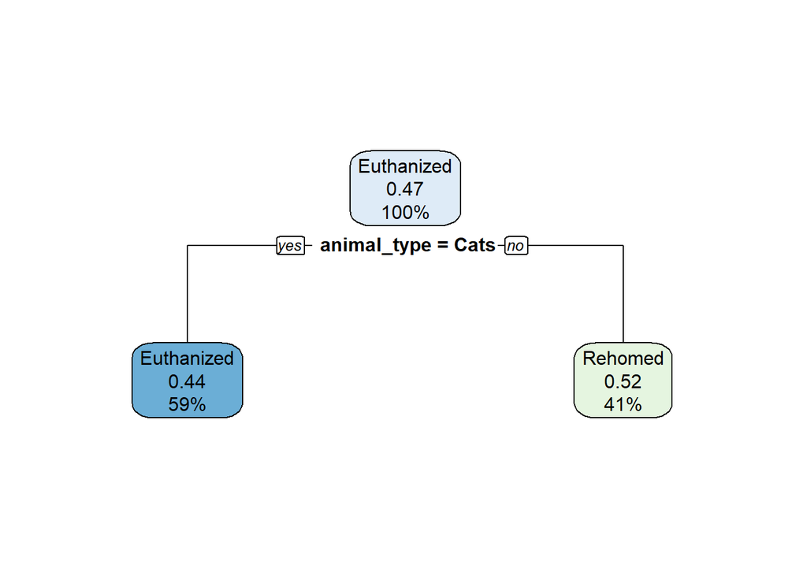

```r
outcome_fit_animal <- rpart(
  formula = outcome ~ animal_type,
  data = outcomes_train,
  method = 'class'
)

rpart.plot(outcome_fit_animal,
           yesno = 2,
           fallen.leaves = TRUE,
           faclen = 6,
           digits = 2)
```

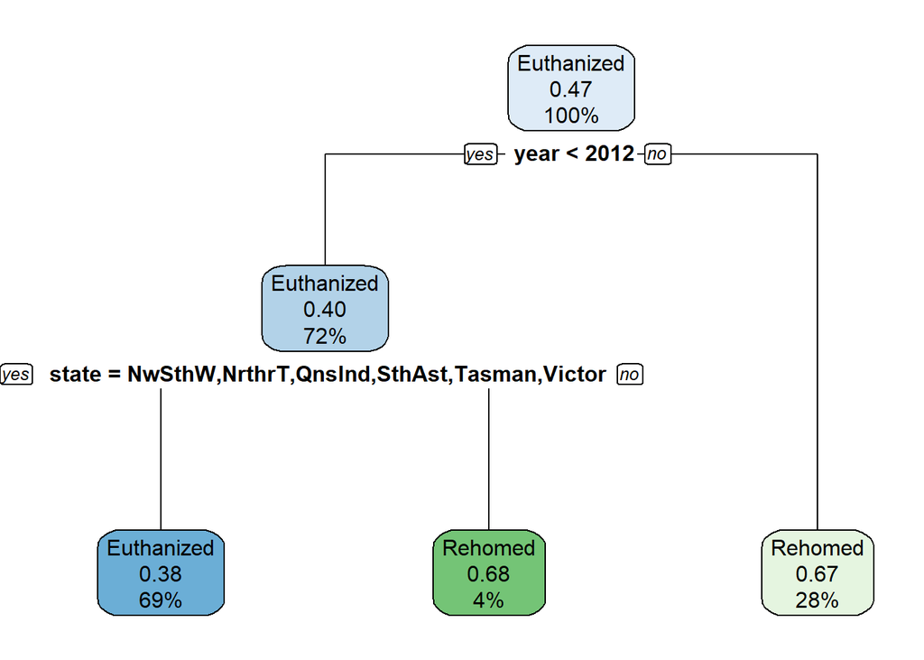

```r
outcome_fit_all <- rpart(
  formula = outcome ~ .,
  data = outcomes_train,
  method = 'class'
)

rpart.plot(outcome_fit_all,
           yesno = 2,
           fallen.leaves = TRUE,
           faclen = 6,
           digits = 2)
```

If the change of trend on euthanasia and rehomeming started in 2012 doesn’t change, a dog or cat in RSPCA care could have the 67% chance to be rehomed.

## Conclusions

**• What is the total call volume for complaint calls regarding pets in Brisbane and Townsville?**

In Brisbane there are more than 13k calls regarding dogs and more than 2k for cats. In Townsville there are more than 38k calls regarding dogs and more than 4k for cats.

It would look like RSPCA is more busy in Townsville beside their being the smaller town (100k people living there vs 2M in Brisbane). As I mentioned before, Townsville data was completed and plenty focused on dogs and cats, while Brisbane was less clear on the animal type for many complaints. So I can’t exclude that the more numbers for Townsville are a consequence of them gathering data better than in Townsville.

**• Is there a particular animal being called about the most?**

Dogs, by a long margin.

**• Do particular suburbs have different type of complaint calls?**

Inala in Brisbane is dealing with a fox problem, they seems to molest cats in particular. Also in Inala there are a lot of complaints regarding dogs and fences. Would be useful to suggest a campaign that invites pets owners to keep their animal is if possible, in particular cats, and a campaign of general advise on how to teach a dog to behave in the yard and not chew the neighbour fence.

**• How have the different outcomes trended over time? Did RSPCA work have an impact?**

Since the 2010s euthanisations have dropped drastically. Rehoming are rising for cats, although I express my doubt on how many of this are successful, considering the disparity of reclaimed and euthanised cats compared with dogs.

Beside this, the number of euthanisation dropping since 2012 if a general sign of things getting better: more animals are rehomed or reclaimed or don’t even get in RSPCA care because they have good owners.

**• Using the insights found, can we predict how this might look for the upcoming year?**